# Movies Dataset Investigation

- Introduction
- Data Wrangling
- Exploratory Data Analysis
- Conclusions

## Introduction

### This data set contains information about 10,000 movies collected from The Movie Database (TMDb), including user ratings and revenue. We are going to investigate factors that may be attributed with higher revenue (adjusted for inflation) and genres that have been most popular with time.

```python
import pandas as pd
import numpy as np
% matplotlib inline
import matplotlib.pyplot as plt
```

```python
def scacorr(a):
    print(a.describe())
    axes = pd.plotting.scatter_matrix(a, alpha=0.01,figsize=(16,16));
    corr = a.corr().as_matrix()
    for i, j in zip(*plt.np.triu_indices_from(axes, k=1)):
        axes[i, j].annotate("%.3f" %corr[i,j], (0.8, 0.8), xycoords='axes fraction', ha='center', va='center')

    return plt.show()
```

## Data Wrangling

### General Properties

| Attribute | Description |
| --- | --- |
| budget_adj | budget adjusted for inflation |
| revenue_adj | revenue adjusted for inflation |

```python
mvs= pd.read_csv('tmdb-movies.csv')
mvs.head(1)
```

|  | id | imdb_id | popularity | budget | revenue | original_title | cast | homepage | director | tagline | ... | overview | runtime | genres | production_companies | release_date | vote_count | vote_average | release_year | budget_adj | revenue_adj |
| --- | --- | --- | --- | --- | --- | --- | --- | --- | --- | --- | --- | --- | --- | --- | --- | --- | --- | --- | --- | --- | --- |
| 0 | 135397 | tt0369610 | 32.985763 | 150000000 | 1513528810 | Jurassic World | Chris Pratt\|Bryce Dallas Howard\|Irrfan Khan\|Vi... | http://www.jurassicworld.com/ | Colin Trevorrow | The park is open. | ... | Twenty-two years after the events of Jurassic ... | 124 | Action\|Adventure\|Science Fiction\|Thriller | Universal Studios\|Amblin Entertainment\|Legenda... | 6/9/15 | 5562 | 6.5 | 2015 | 1.379999e+08 | 1.392446e+09 |

1 rows × 21 columns

```python
mvs.shape
```

```
(10866, 21)
```

```python
mvs.dtypes
```

```
id                        int64
imdb_id                  object
popularity              float64
budget                    int64
revenue                   int64
original_title           object
cast                     object
homepage                 object
director                 object
tagline                  object
keywords                 object
overview                 object
runtime                   int64
genres                   object
production_companies     object
release_date             object
vote_count                int64
vote_average            float64
release_year              int64
budget_adj              float64
revenue_adj             float64
dtype: object
```

```python
mvs.info()
```

```
<class 'pandas.core.frame.DataFrame'>
RangeIndex: 10866 entries, 0 to 10865
Data columns (total 21 columns):
id                      10866 non-null int64
imdb_id                 10856 non-null object
popularity              10866 non-null float64
budget                  10866 non-null int64
revenue                 10866 non-null int64
original_title          10866 non-null object
cast                    10790 non-null object
homepage                2936 non-null object
director                10822 non-null object
tagline                 8042 non-null object
keywords                9373 non-null object
overview                10862 non-null object
runtime                 10866 non-null int64
genres                  10843 non-null object
production_companies    9836 non-null object
release_date            10866 non-null object
vote_count              10866 non-null int64
vote_average            10866 non-null float64
release_year            10866 non-null int64
budget_adj              10866 non-null float64
revenue_adj             10866 non-null float64
dtypes: float64(4), int64(6), object(11)
memory usage: 1.7+ MB
```

```python
sum(mvs.duplicated())
```

```
1
```

```python
mvs.describe()
```

|  | id | popularity | budget | revenue | runtime | vote_count | vote_average | release_year | budget_adj | revenue_adj |
| --- | --- | --- | --- | --- | --- | --- | --- | --- | --- | --- |
| count | 10866.000000 | 10866.000000 | 1.086600e+04 | 1.086600e+04 | 10866.000000 | 10866.000000 | 10866.000000 | 10866.000000 | 1.086600e+04 | 1.086600e+04 |
| mean | 66064.177434 | 0.646441 | 1.462570e+07 | 3.982332e+07 | 102.070863 | 217.389748 | 5.974922 | 2001.322658 | 1.755104e+07 | 5.136436e+07 |
| std | 92130.136561 | 1.000185 | 3.091321e+07 | 1.170035e+08 | 31.381405 | 575.619058 | 0.935142 | 12.812941 | 3.430616e+07 | 1.446325e+08 |
| min | 5.000000 | 0.000065 | 0.000000e+00 | 0.000000e+00 | 0.000000 | 10.000000 | 1.500000 | 1960.000000 | 0.000000e+00 | 0.000000e+00 |
| 25% | 10596.250000 | 0.207583 | 0.000000e+00 | 0.000000e+00 | 90.000000 | 17.000000 | 5.400000 | 1995.000000 | 0.000000e+00 | 0.000000e+00 |
| 50% | 20669.000000 | 0.383856 | 0.000000e+00 | 0.000000e+00 | 99.000000 | 38.000000 | 6.000000 | 2006.000000 | 0.000000e+00 | 0.000000e+00 |
| 75% | 75610.000000 | 0.713817 | 1.500000e+07 | 2.400000e+07 | 111.000000 | 145.750000 | 6.600000 | 2011.000000 | 2.085325e+07 | 3.369710e+07 |
| max | 417859.000000 | 32.985763 | 4.250000e+08 | 2.781506e+09 | 900.000000 | 9767.000000 | 9.200000 | 2015.000000 | 4.250000e+08 | 2.827124e+09 |

```python
mvs[mvs['revenue_adj']==0].shape
mvs[mvs['budget_adj']==0].shape
```

```
(5696, 21)
```

#### more than half of the data is having the value of zero as revenue and budget

#### In the previous cells, we have determined shape of our data, types of attibutes, duplicated samples, descriptive statistics for each column of data and number of non-null values in each column.

### Data Cleaning

#### Dropping Duplicates and checking for duplicates

```python
# After discussing the structure of the data and any problems that need to be
#   cleaned, perform those cleaning steps in the second part of this section.
mvs.drop_duplicates(inplace=True)
```

```python
sum(mvs.duplicated())
```

```
0
```

#### Replacing zero values in a column with the mean of that column

```python
mvs['revenue_adj'] = mvs['revenue_adj'].replace(0,  mvs['revenue_adj']. mean())
mvs['budget_adj'] = mvs['budget_adj'].replace(0,  mvs['budget_adj']. mean())
```

#### Correcting Data Types

```python
mvs['release_date']=pd.to_datetime(mvs['release_date'])
```

#### Dropping Extraneous Columns and Rows with Null values

```python
mvs.drop(['id','homepage','overview','tagline','keywords','imdb_id','budget','revenue'],axis=1,inplace=True)
```

```python
mvs.dropna(inplace=True)
```

```python
mvs.info()
```

```
<class 'pandas.core.frame.DataFrame'>
Int64Index: 9772 entries, 0 to 10865
Data columns (total 13 columns):
popularity              9772 non-null float64
original_title          9772 non-null object
cast                    9772 non-null object
director                9772 non-null object
runtime                 9772 non-null int64
genres                  9772 non-null object
production_companies    9772 non-null object
release_date            9772 non-null datetime64[ns]
vote_count              9772 non-null int64
vote_average            9772 non-null float64
release_year            9772 non-null int64
budget_adj              9772 non-null float64
revenue_adj             9772 non-null float64
dtypes: datetime64[ns](1), float64(4), int64(3), object(5)
memory usage: 1.0+ MB
```

#### We are going to split genre column into a new dataframe known as mvs_genre to be used in our investigation

```python
mvs_g=mvs.genres.str.split('|', expand=True).stack()
mvs_g.head(10)
```

```
0  0             Action
   1          Adventure
   2    Science Fiction
   3           Thriller
1  0             Action
   1          Adventure
   2    Science Fiction
   3           Thriller
2  0          Adventure
   1    Science Fiction
dtype: object
```

```python
mvs_edit = pd.concat([mvs_g], axis=1, keys=('genre')).ffill().reset_index(level=1, drop=True)
mvs_edit.head()
```

|  | g |
| --- | --- |
| 0 | Action |
| 0 | Adventure |
| 0 | Science Fiction |
| 0 | Thriller |
| 1 | Action |

```python
mvs_genre=mvs.join(mvs_edit).reset_index(drop=True)[['g','popularity','original_title','director','vote_average','release_year','budget_adj','revenue_adj']]
mvs_genre.rename(columns={'g':'genres'}, inplace=True)
mvs_genre.head()
```

|  | genres | popularity | original_title | director | vote_average | release_year | budget_adj | revenue_adj |
| --- | --- | --- | --- | --- | --- | --- | --- | --- |
| 0 | Action | 32.985763 | Jurassic World | Colin Trevorrow | 6.5 | 2015 | 1.379999e+08 | 1.392446e+09 |
| 1 | Adventure | 32.985763 | Jurassic World | Colin Trevorrow | 6.5 | 2015 | 1.379999e+08 | 1.392446e+09 |
| 2 | Science Fiction | 32.985763 | Jurassic World | Colin Trevorrow | 6.5 | 2015 | 1.379999e+08 | 1.392446e+09 |
| 3 | Thriller | 32.985763 | Jurassic World | Colin Trevorrow | 6.5 | 2015 | 1.379999e+08 | 1.392446e+09 |
| 4 | Action | 28.419936 | Mad Max: Fury Road | George Miller | 7.1 | 2015 | 1.379999e+08 | 3.481613e+08 |

## Exploratory Data Analysis

```
        popularity      runtime   vote_count  vote_average  release_year  \
count  9772.000000  9772.000000  9772.000000   9772.000000   9772.000000
mean      0.694721   102.926627   239.312014      5.963528   2000.878428
std       1.036931    27.877432   603.011504      0.913174     13.036794
min       0.000188     0.000000    10.000000      1.500000   1960.000000
25%       0.232710    90.000000    18.000000      5.400000   1994.000000
50%       0.419762   100.000000    46.000000      6.000000   2005.000000
75%       0.776408   112.000000   173.000000      6.600000   2011.000000
max      32.985763   877.000000  9767.000000      8.700000   2015.000000

         budget_adj   revenue_adj
count  9.772000e+03  9.772000e+03
mean   2.794849e+07  8.345251e+07
std    3.190092e+07  1.434701e+08
min    9.210911e-01  2.370705e+00
25%    1.754989e+07  4.908911e+07
50%    1.754989e+07  5.136900e+07
75%    2.464268e+07  5.136900e+07
max    4.250000e+08  2.827124e+09
```

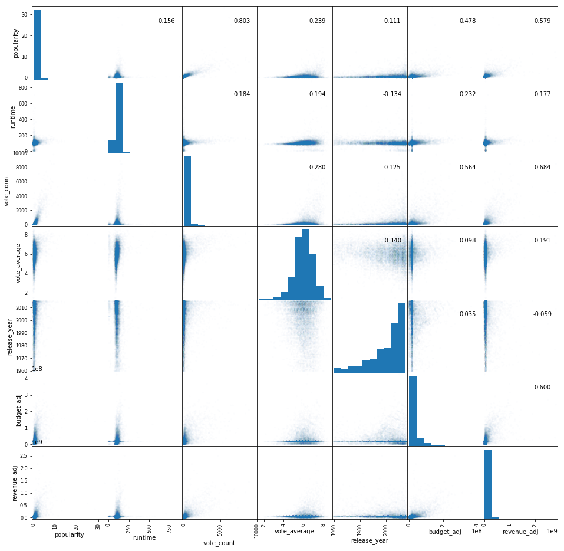

```python
scacorr(mvs)
```

[output not shown]

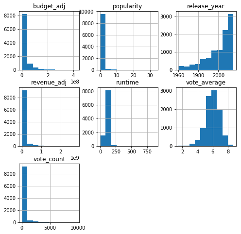

```python
mvs.hist(figsize=(8,8))
```

### What kinds of properties are associated with movies that have high revenues?

### First, we will create a sub dataframe containing movies with revenue greater than or equal 200M$

```python
mvs_highrev=mvs[mvs['revenue_adj']>=2e+8]
mvs_highrev.head(1)
```

|  | popularity | original_title | cast | director | runtime | genres | production_companies | release_date | vote_count | vote_average | release_year | budget_adj | revenue_adj |
| --- | --- | --- | --- | --- | --- | --- | --- | --- | --- | --- | --- | --- | --- |
| 0 | 32.985763 | Jurassic World | Chris Pratt\|Bryce Dallas Howard\|Irrfan Khan\|Vi... | Colin Trevorrow | 124 | Action\|Adventure\|Science Fiction\|Thriller | Universal Studios\|Amblin Entertainment\|Legenda... | 2015-06-09 | 5562 | 6.5 | 2015 | 1.379999e+08 | 1.392446e+09 |

```python
mvs_highrev.revenue_adj.nlargest(10).reset_index()
```

|  | index | revenue_adj |
| --- | --- | --- |
| 0 | 1386 | 2.827124e+09 |
| 1 | 1329 | 2.789712e+09 |
| 2 | 5231 | 2.506406e+09 |
| 3 | 10594 | 2.167325e+09 |
| 4 | 9806 | 1.907006e+09 |
| 5 | 3 | 1.902723e+09 |
| 6 | 8889 | 1.791694e+09 |
| 7 | 8094 | 1.583050e+09 |
| 8 | 10110 | 1.574815e+09 |
| 9 | 4361 | 1.443191e+09 |

```python
mvs_highrev.sort_values(by=['revenue_adj'],ascending=False)
mvs_highrev.head()
```

|  | popularity | original_title | cast | director | runtime | genres | production_companies | release_date | vote_count | vote_average | release_year | budget_adj | revenue_adj |
| --- | --- | --- | --- | --- | --- | --- | --- | --- | --- | --- | --- | --- | --- |
| 0 | 32.985763 | Jurassic World | Chris Pratt\|Bryce Dallas Howard\|Irrfan Khan\|Vi... | Colin Trevorrow | 124 | Action\|Adventure\|Science Fiction\|Thriller | Universal Studios\|Amblin Entertainment\|Legenda... | 2015-06-09 | 5562 | 6.5 | 2015 | 1.379999e+08 | 1.392446e+09 |
| 1 | 28.419936 | Mad Max: Fury Road | Tom Hardy\|Charlize Theron\|Hugh Keays-Byrne\|Nic... | George Miller | 120 | Action\|Adventure\|Science Fiction\|Thriller | Village Roadshow Pictures\|Kennedy Miller Produ... | 2015-05-13 | 6185 | 7.1 | 2015 | 1.379999e+08 | 3.481613e+08 |
| 2 | 13.112507 | Insurgent | Shailene Woodley\|Theo James\|Kate Winslet\|Ansel... | Robert Schwentke | 119 | Adventure\|Science Fiction\|Thriller | Summit Entertainment\|Mandeville Films\|Red Wago... | 2015-03-18 | 2480 | 6.3 | 2015 | 1.012000e+08 | 2.716190e+08 |
| 3 | 11.173104 | Star Wars: The Force Awakens | Harrison Ford\|Mark Hamill\|Carrie Fisher\|Adam D... | J.J. Abrams | 136 | Action\|Adventure\|Science Fiction\|Fantasy | Lucasfilm\|Truenorth Productions\|Bad Robot | 2015-12-15 | 5292 | 7.5 | 2015 | 1.839999e+08 | 1.902723e+09 |
| 4 | 9.335014 | Furious 7 | Vin Diesel\|Paul Walker\|Jason Statham\|Michelle ... | James Wan | 137 | Action\|Crime\|Thriller | Universal Pictures\|Original Film\|Media Rights ... | 2015-04-01 | 2947 | 7.3 | 2015 | 1.747999e+08 | 1.385749e+09 |

```
       popularity     runtime   vote_count  vote_average  release_year  \
count  799.000000  799.000000   799.000000    799.000000    799.000000
mean     2.386477  118.186483  1399.663329      6.497372   1999.018773
std      2.499058   23.187187  1431.652361      0.704572     13.089949
min      0.044675   78.000000    10.000000      4.400000   1960.000000
25%      1.102782  100.000000   392.500000      6.000000   1993.000000
50%      1.774018  115.000000   871.000000      6.500000   2002.000000
75%      2.773376  131.000000  1929.000000      7.000000   2010.000000
max     32.985763  248.000000  9767.000000      8.300000   2015.000000

         budget_adj   revenue_adj
count  7.990000e+02  7.990000e+02
mean   9.040722e+07  4.508695e+08
std    5.901182e+07  3.027835e+08
min    2.248029e+02  2.001783e+08
25%    4.250106e+07  2.571896e+08
50%    8.091114e+07  3.481613e+08
75%    1.260967e+08  5.397121e+08
max    3.683713e+08  2.827124e+09
```

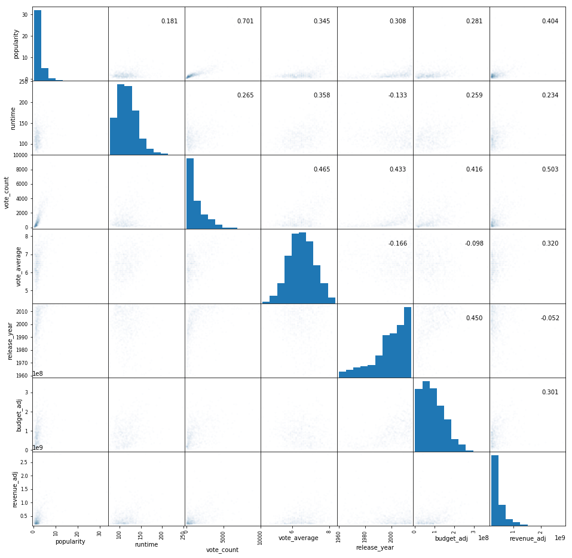

```python
scacorr(mvs_highrev)
```

#### we can't rely on correlations as we can see pearson's coef. in most cases is far from1.

#### mean of vote_average for high revenue movies is approximately 6.5 with 50% of movies produced starting from 2002

```python
mvs_highrev['director'].value_counts().head(10)
```

```
Steven Spielberg    20
Robert Zemeckis     10
Ridley Scott        10
Ron Howard           9
Michael Bay          9
Peter Jackson        7
Tim Burton           7
Roland Emmerich      7
David Fincher        7
Chris Columbus       7
Name: director, dtype: int64
```

```
Text(0,0.5,'No. of movies')
```

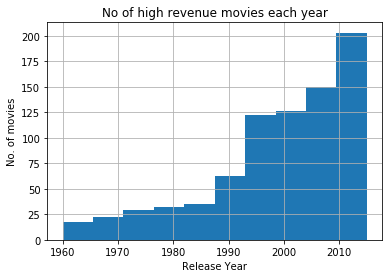

```python
mvs_highrev['release_year'].hist()
plt.title("No of high revenue movies each year")
plt.xlabel("Release Year")
plt.ylabel("No. of movies")
```

#### we can see that no of high revenue movies have been increasing starting from the 90s and continues to go up thoughout years

```python
highrev_genres=mvs_genre[mvs_genre['revenue_adj']>=2e+8]
```

```
Text(0,0.5,'No. of movies')
```

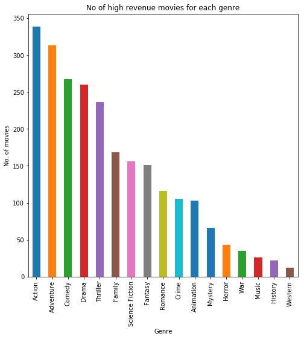

```python
a=highrev_genres['genres'].value_counts()
a.plot(x=a,y=a.index,kind='bar',figsize=(8,8));
plt.title("No of high revenue movies for each genre")
plt.xlabel("Genre")
plt.ylabel("No. of movies")
```

#### The prevoius figure shows than action and adventure are movies high revenue with more than 300 movies while western, music and history are movies with least revenue less than 50 movies